# The Cost of Life: Economic Development and Infant Survival

- Show All Code
- Hide All Code
- View Source

A Data-Driven Look at Global Health Inequalities

Author

Tanvee

Published

April 7, 2026

## Personal Introduction

When we examine global health statistics, it is easy to overlook the fact that behind every single data point, there is a life. For this task, I decided to examine UNICEF’s statistics on Infant Mortality Rates since it is one of the most tragic and sensitive measures of a country’s overall wellbeing.

I don’t want to just plot numbers here; I want to tell a story about inequality. By linking infant mortality records with macroeconomic indicators such as GDP per capita, I want to investigate a painful question: How much does wealth determine whether the youngest members of society live or die?

### Data Preperation and Quality Checks

So firstly we load data using polars and do some Exploratory Data Analysis (EDA) We’ll merge the indicator data (Infant Mortality) with the metadata (GDP, Life Expectancy, etc.) on both country code and year.

```python
import polars as pl
import plotnine as p9
import geopandas as gpd
import pandas as pd

# Load the data
indicator_df = pl.read_csv("unicef_indicator_1.csv")
metadata_df = pl.read_csv("unicef_metadata.csv")

# Filter for Total sex and rename columns for clarity
ind_clean = indicator_df.filter(
    pl.col("sex") == "Total"
).select(
    ["country", "alpha_3_code", "time_period", "obs_value"]
).rename({
    "time_period": "year",
    "obs_value": "infant_mortality_rate"
})

# Create a new DataFrame with relevant columns from metadata
meta_clean = metadata_df.select(
    ["alpha_3_code", "year",
     "Population, total",
     "GDP per capita (constant 2015 US$)",
     "Life expectancy at birth, total (years)"]
).rename({
    "Population, total": "population",
    "GDP per capita (constant 2015 US$)": "gdp_per_capita",
    "Life expectancy at birth, total (years)": "life_expectancy"
})

# Join the datasets
merged_df = ind_clean.join(
    meta_clean,
    on=["alpha_3_code", "year"],
    how="inner"
)

# Convert to pandas for compatibility with plotnine and geopandas
df_pd = merged_df.to_pandas()

# Exploratory Data analysis and have some look on Quality of data for 2020
df_2020 = df_pd[df_pd['year'] == 2020]
missing_gdp = df_2020['gdp_per_capita'].isna().sum()

print("--- Summary for EDA 2020 ---")
print(f"Total countries analyzed: {len(df_2020)}")
print(f"Countries missing GDP data: {missing_gdp}")
print(df_2020[['infant_mortality_rate', 'gdp_per_capita']].describe())
```

```
--- Summary for EDA 2020 ---
Total countries analyzed: 194
Countries missing GDP data: 5
       infant_mortality_rate  gdp_per_capita
count             194.000000      189.000000
mean               20.128730    13949.615183
std                18.193437    20985.529930
min                 1.531810      263.463876
25%                 5.413406     1947.839929
50%                13.627926     5569.584833
75%                31.414390    17048.361730
max                74.473541   161262.925884
```

## A World of Divides: Mapping Mortality

To get a scope of the world, we extract infant mortality rates around the world for 2020.

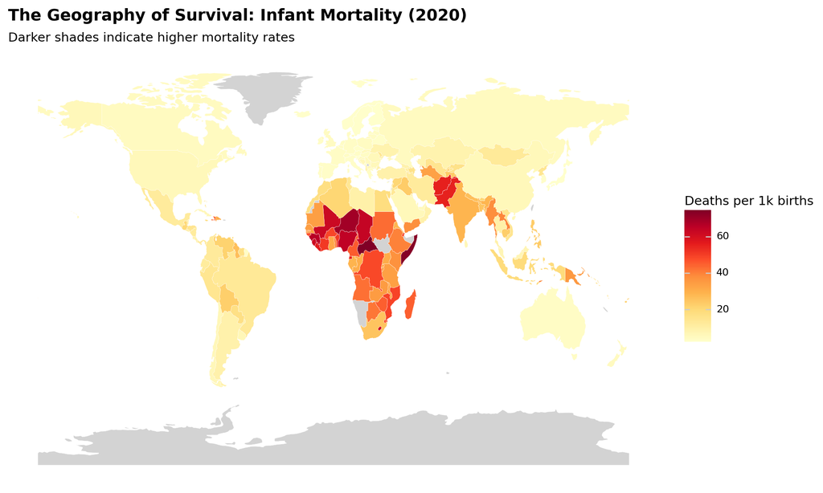

Figure 1: Infant Mortality Rate by Country (2020)

```python
# Load world map data
import urllib.request
import tempfile
import zipfile
import os

url = "https://naciscdn.org/naturalearth/110m/cultural/ne_110m_admin_0_countries.zip"
temp_dir = tempfile.mkdtemp()
zip_path = os.path.join(temp_dir, "ne.zip")
urllib.request.urlretrieve(url, zip_path)
with zipfile.ZipFile(zip_path, 'r') as zip_ref:
    zip_ref.extractall(temp_dir)
world = gpd.read_file(os.path.join(temp_dir, "ne_110m_admin_0_countries.shp"))
world = world.rename(columns={'ADM0_A3': 'iso_a3'})

# Combine map data with our df
world_merged = world.merge(df_2020, left_on='iso_a3', right_on='alpha_3_code', how='left')

# Plot using plotnine
map_plot = (
    p9.ggplot(world_merged)
    + p9.geom_map(p9.aes(fill='infant_mortality_rate'), color='white', size=0.1)
    + p9.scale_fill_cmap(cmap_name='YlOrRd', na_value='lightgrey')
    + p9.theme_minimal()
    + p9.labs(
        title="The Geography of Survival: Infant Mortality (2020)",
        subtitle="Darker shades indicate higher mortality rates",
        fill="Deaths per 1k births"
    )
    + p9.theme(
        figure_size=(10, 6),
        panel_grid=p9.element_blank(),
        axis_text=p9.element_blank(),
        axis_ticks=p9.element_blank(),
        plot_title=p9.element_text(weight='bold', size=14)
    )
)
map_plot
```

## The Hardest Hit Nations

Let’s take a closer look at the 15 countries with the highest rates of infant mortality in 2020.

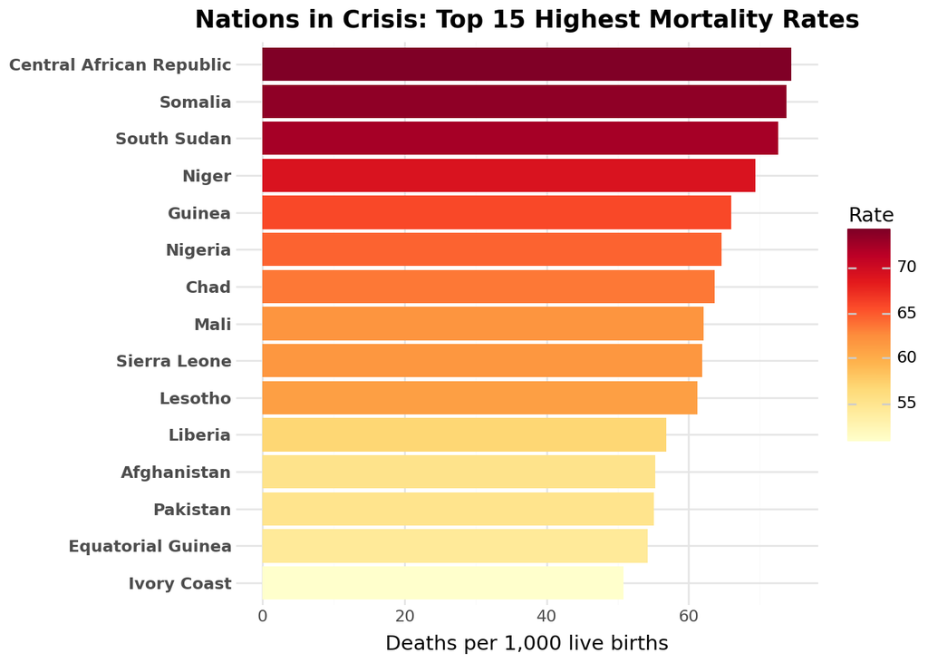

Figure 2: Top 15 Countries by Infant Mortality Rate (2020)

```python
top_15 = df_2020.nlargest(15, 'infant_mortality_rate').copy()

# Reverse country factor order for plotting
top_15['country'] = pd.Categorical(top_15['country'], categories=top_15['country'][::-1], ordered=True)

bar_plot = (
    p9.ggplot(top_15, p9.aes(x='country', y='infant_mortality_rate', fill='infant_mortality_rate'))
    + p9.geom_col()
    + p9.coord_flip()
    + p9.scale_fill_cmap(cmap_name='YlOrRd')
    + p9.theme_minimal()
    + p9.labs(
        title="Nations in Crisis: Top 15 Highest Mortality Rates",
        x="",
        y="Deaths per 1,000 live births",
        fill="Rate"
    )
    + p9.theme(
        plot_title=p9.element_text(weight='bold'),
        axis_text_y=p9.element_text(weight='bold')
    )
)
bar_plot
```

## On the gap between GDP and survival

Is there a straightforward relation between a country being rich and having low rates of infant mortality? We plot a scatterplot with linear regression to see the relationship between GDP per capita vs Infant Mortality Rate Annotation of outlier and benchmark countries in the chart for further usefulness

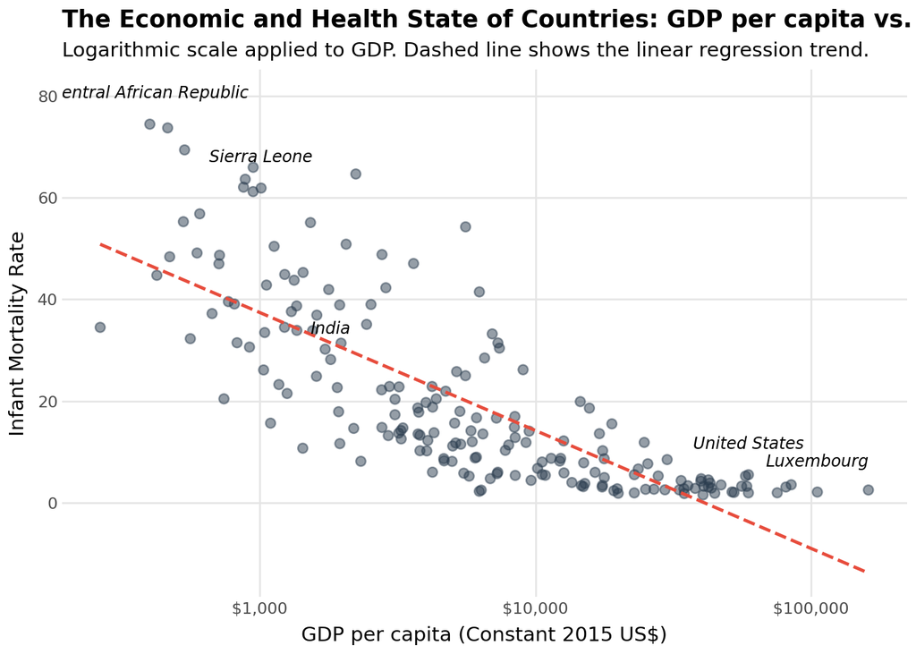

Figure 3: GDP per capita vs Infant Mortality Rate (2020)

```python
# Creating a sut of annotations with just text
annotations = df_2020[df_2020['country'].isin(['Central African Republic', 'United States', 'India', 'Sierra Leone', 'Luxembourg'])]

scatter_plot = (
    p9.ggplot(df_2020.dropna(subset=['gdp_per_capita', 'infant_mortality_rate']),
              p9.aes(x='gdp_per_capita', y='infant_mortality_rate'))
    + p9.geom_point(alpha=0.5, color='#2c3e50', size=2.5)
    + p9.geom_smooth(method='lm', color='#e74c3c', se=False, linetype='dashed', size=1)
    + p9.geom_text(p9.aes(label='country'), data=annotations, nudge_y=6, size=9, fontstyle='italic', color='black')
    + p9.scale_x_log10(labels=lambda breaks: [f"${b:,.0f}" for b in breaks])
    + p9.theme_minimal()
    + p9.labs(
        title="The Economic and Health State of Countries: GDP per capita vs. Infant Mortality",
        subtitle="Logarithmic scale applied to GDP. Dashed line shows the linear regression trend.",
        x="GDP per capita (Constant 2015 US$)",
        y="Infant Mortality Rate"
    )
    + p9.theme(
        plot_title=p9.element_text(weight='bold', size=13),
        panel_grid_minor=p9.element_blank()
    )
)
scatter_plot
```

The scatterplot evidently displays the strong negative correlation: when GDP per capita increases, infant mortality rate significantly decreases. This is illustrated by the red dashed linear regression line.